# Regular Languages

Math 252 — Spring 2018

1. Convert each of the following NFA’s into an equivalent DFA. (Rembember: equivalent means that they recognize the same language.) Do this using our general algorithm for this task. For the first two, the start state is $S$.

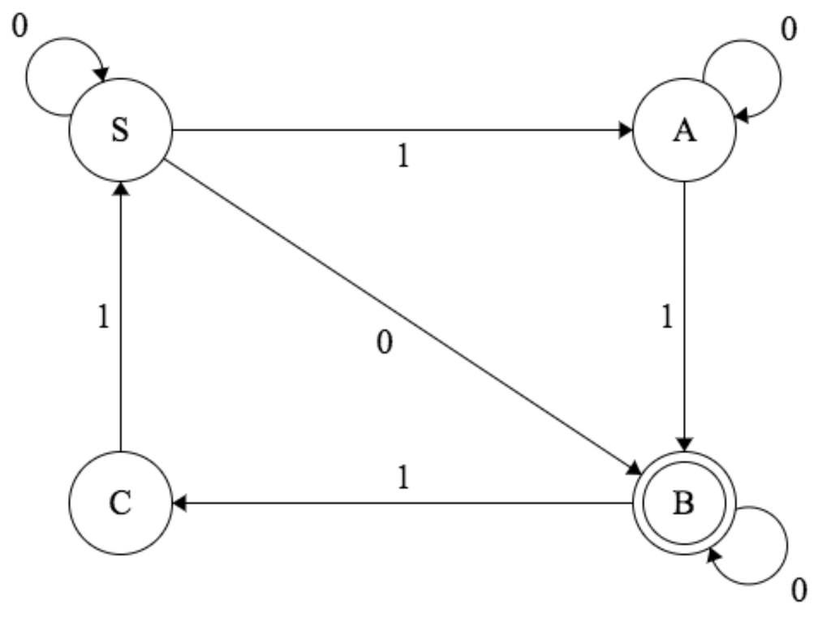

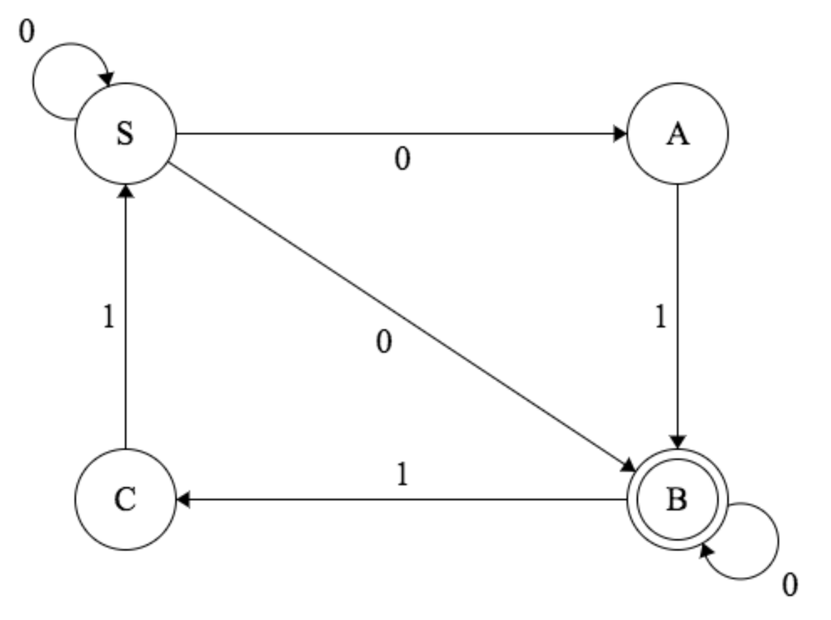

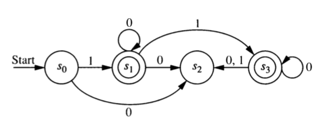

## Operations on Languages

Since languages are sets, we can use set operations like $\cup$ and $\cap$ to create new languages. But there are some additional operations that we will use.

- concatenation of strings: $xy$ is the concetanation of strings $x$ and $y$ ($x$ followed by $y$)
- concatenation of sets: $AB = \{ xy \mid x \in A \land y \in B \}$
- power: $A^0 = \emptyset$; $A^1 = A$; $A^{n+1} = A^n A$. (Power is iterated concatenation.)
- Kleene star: $\displaystyle A^* = \cup_{n = 0}^{\infty} \; A^n$
2. Which of these strings belong to $\{0, 01\}^*$?
   1. 01001
   2. 10110
   3. 00010
3. Which of these strings belong to $\{011, 110, 11\}^*$?
   1. 0101111
   2. 0110110
   3. 00010

## Regular Expressions

### Syntax

A regular expression over an input alphabet $I$ is defined recursively.

- $\bm{\emptyset}$ and $\bm{\lambda}$ and regular expressions.
- $\bm{x}$ is a regular expression for each $i \in I$.
- If $\bm{A}$ and $\bm{B}$ are regular expressions, then
  - $\bm{A}^*$ is a regular expression
  - $(\bm{A} \cup \bm{B})$ is a regular expression
  - $(\bm{AB})$ is a regular expression

### Semantics

Each regular expression represents a language as follows.

- $\bm{\emptyset}$ represents the empty langauge: $\emptyset$
- $\bm{\lambda}$ represents language that contains only the empty string: $\{\lambda\}$
- For each $x \in I$, $\bm{x}$ represents the language containing only $x$: $\{x \}$
- If $\bm{A}$ and $\bm{B}$ are regular expressions representing languages $A$ and $B$, then
  - $(\bm{AB})$ encodes $AB$
  - $(\bm{A \cup B})$ encodes $A \cup B$ [Note: This is often written `(A|B)` in programming languages.]
  - $\bm{A}^*$ encodes $A^*$ [Note: This is often written as `A*` in programming languages.]

The langauges represented by regular expressions are called **regular languages** (how creative).

4. Describe in words the languages represented by each of these regular expressions.
   1. $\bm{10^*}$
   2. $\bm{(10)^*}$
   3. $\bm{0 \cup 01}$
   4. $\bm{0^* \cup 01}$
   5. $\bm{0 (0 \cup 1)^*}$
   6. $\bm{(0 \cup 01)^*}$
5. Can each of the languages above be recongized by an NFA? a DFA?
6. What would we need to do to show that every regualar language can be recognized by an NFA? Give it a try and see how far you get. Which parts are easy? Which are trickier? Why?

## Recognizing Regular Languages with NFAs

1. Show that empty language ($\emptyset$) is recognized by an NFA.
2. Show that the language $\{\lambda\}$ is recognized by an NFA.
3. Show that if $i \in I$, then the langauge $\{i \}$ is recognized by an NFA.
4. Show that if $A$ and $B$ are each recognized by an NFA, then $AB$ is, too.
5. Show that if $A$ and $B$ are each recognized by an NFA, then $A \cup B$ is, too.
6. Show that if $A$ is recognized by an NFA, then $A^*$ is, too.
7. Explain how the results above show that every regular language is recognized by an NFA.
8. Show that if $A$ is recognized by an NFA, then the complement of $A$ ($\overline{A} = A^C$) is too.

   [Hint: there is an easy way and a hard way – use the easy way.]